# Tree Methods Lab 1: BART

Ander Wilson

## Lab overview

- BART with covariates included in the tree model.

We will fit the BART model in the lab. This only takes a minute or so. Some of the post-processing for partial dependence plots is slower. We will skip this. These steps were run in advance and output from these steps will be used in the lab.

## Setup

Load the packages used in this lab.

```r
## load required libraries
#install.packages("corrplot")
library(corrplot)
#install.packages("ggplot2")
library(ggplot2)
#install.packages("tidyverse")
library(tidyverse)
#install.packages("BART")
library(BART)
```

### Lab-specific package

Uncomment the below and then load `bartmix` library when running for first time

This package has some functions to post-process the MCMC from BART models. You can adapt the code in this package to meet other estimation needs with BART.

```r
# install.packages("remotes")
# remotes::install_github("AnderWilson/bartmix")
library(bartmix)
```

## Load and format data

Load in the data and do some data preparation. The packages used here (`randomForests` and `BART`) can handle cateogrical predictors. We therefore do less data preparation because we do not need to make dummy variables.

```r
## read in data and only consider complete data
## this drops 327 individuals
## some tree methods handle missing data but we will not deal with that here
nhanes <- na.omit(read.csv(paste0(here::here(),"/Data/studypop.csv")))
```

```r
## our y variable - ln transformed and scaled mean telomere length
## some tree methods make assumptions about the error variance and some do not
## generally safer to transform the dependent variable to reduce heteroskedasticity
lnLTL_z <- scale(log(nhanes$TELOMEAN))
```

```r
## exposures matrix
mixture <- with(nhanes, cbind(LBX074LA, LBX099LA, LBX118LA, LBX138LA, LBX153LA, LBX170LA, LBX180LA, LBX187LA, LBX194LA, LBXHXCLA, LBXPCBLA,
                              LBXD03LA, LBXD05LA, LBXD07LA,
                              LBXF03LA, LBXF04LA, LBXF05LA, LBXF08LA))
# Most tree models are invariant the transformations of the predictors (they don't make a difference)
# here we transform it to make the plots consistent with other methods so they can be compared
mixture   <- apply(mixture, 2, log)
mixture <- scale(mixture)
colnames(mixture) <- c(paste0("PCB",c(74, 99, 118, 138, 153, 170, 180, 187, 194, 169, 126)),
                           paste0("Dioxin",1:3), paste0("Furan",1:4))
exposure_names <- colnames(mixture)
```

```r
## our X matrix
covariates <- with(nhanes, cbind(age_cent, male, bmi_cat3, edu_cat, race_cat,
                                 LBXWBCSI, LBXLYPCT, LBXMOPCT,
                                 LBXNEPCT, LBXEOPCT, LBXBAPCT, ln_lbxcot))
```

## Fit BART

We fit the BART model with default parameters: 200 trees, 2000 MCMC iteration discarded for burning, 2000 iterations retained for analysis.

```r
# fit the BART model
set.seed(1000)
fit_bart <- gbart(x.train=cbind(mixture,covariates),
                  y.train=lnLTL_z,
                  nskip=2000,    # MCMC iterations that are discarded as burning
                  ndpost=2000)   # MCMC iterations after burning that are retained for
```

[output not shown]

```r
load(paste0(here::here(), "/Supervised/Tree Based Methods/bart_fits_for_lab.rda"))
```

## Fitted values

Fitted values in BART are the estimated mean response at the observed values. Note that this is very different that the random forest plot because the covariates have not been regressed out of the outcome (see other lab document).

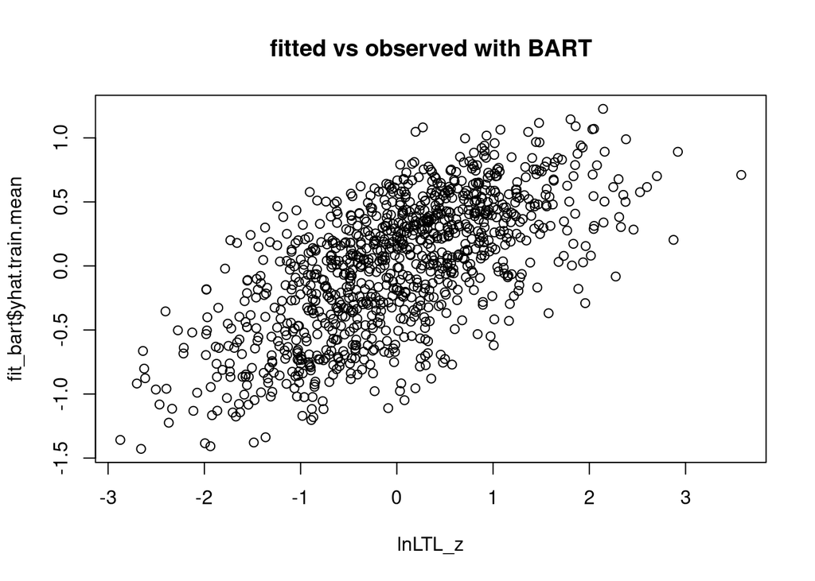

```r
plot(fit_bart$yhat.train.mean~lnLTL_z,
     main="fitted vs observed with BART")
```

## Variable importance

A simple measure of variable importance in BART is how many trees each variable is included in. We get an estimate of this with uncertainty. A variable being included in a lot of trees does not necessarily mean the variable has a large association or an association at all.

BART can be extended to do variable selection (use `sparse=TRUE`). Variable selection will be applied to all predictors including covariates. It may be more appropriate when covariates are regressed out of the outcome. This is likely to lead to more useful measures of variable importance.

The `bartMachines` package has additional variable importance measures.

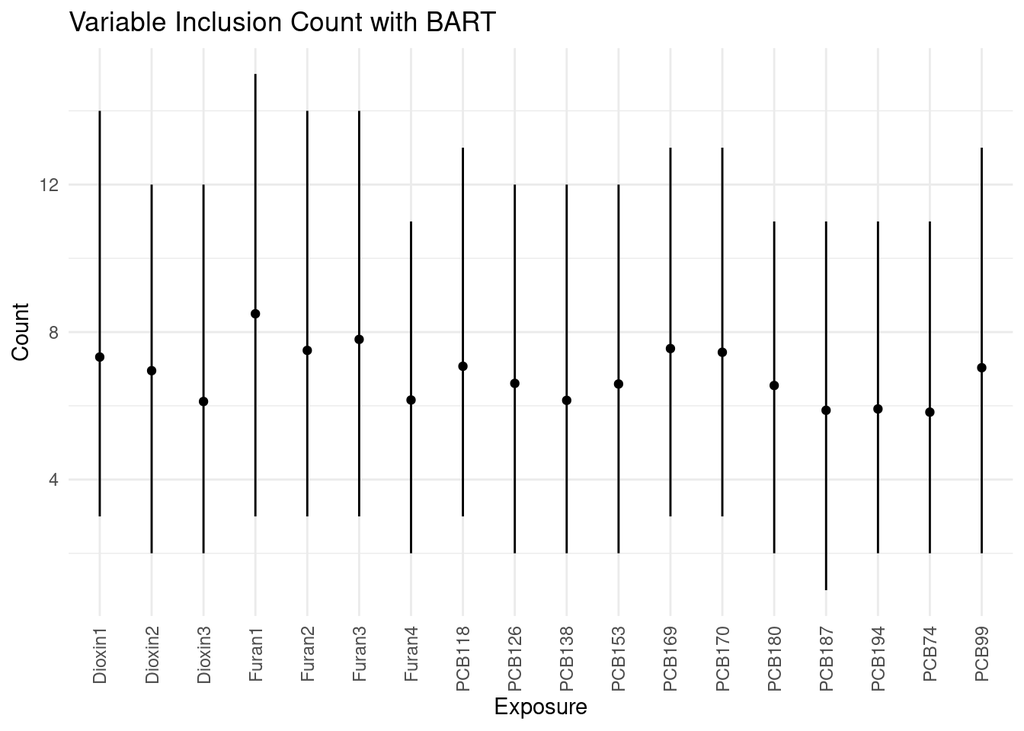

```r
# variable importance for the mixture components with BART
varcount <- data.frame(exposure=exposure_names,
                       mean=fit_bart$varcount.mean[exposure_names],
                       lower=apply(fit_bart$varcount[,exposure_names],2,quantile,0.025),
                       upper=apply(fit_bart$varcount[,exposure_names],2,quantile,0.975))

# visualize the variable importance with BART
ggplot(varcount, aes(x=exposure, y=mean, ymin=lower, ymax=upper)) +
  geom_errorbar(width=0) +
  geom_point() +
  theme_minimal() +
  ggtitle("Variable Inclusion Count with BART") +
  xlab("Exposure") +
  ylab("Count") +
  theme(axis.text.x = element_text(angle = 90, vjust = 0.5, hjust=1))
```

## Estimation a contrast in exposures

We can estimate an IQR change in furan 1 when all other variables (exposures and covariates) are fixed at the sample means. The general idea is to create a data frame with two observations. Each observation represents one potential exposure profile. In our case, these exposure profiles will have all variables (exposures and covariates) set to their means, with the exception on furan 1. For furan 1, one observations will have exposure at the 75th percentile and one at the 25th percentile. We will compare the estimated mean response for observations with these two exposure profiles. This can be generalized to any exposure (or covariate) profiles. There is nothin special about setting these to the mean.

The first step is to setup the data. The data should have: - two rows, one for each quantile of furan 1 we are considering, - one column for each variable in the training data, - all variable set to the mean with the exception of furan 1, and - furan 1 set to the quantiles we which to compare (25th in one row and 75th in the other row).

```r
# find the means
# note that we really should use mode or something other than mean for factor variables
data_means <- colMeans(cbind(mixture,covariates))

# Find the 25th and 75th quantiles of furan 1
furan_qntls <- quantile(mixture[,"Furan1"], probs=c(0.25,0.75))

# create a new dataset with two rows
# each row has the means for all variables except furan 1
# each row has one of the furan 1 quantiles
new_data <- rbind(data_means,data_means) # everything set to mean
new_data[,"Furan1"] <- furan_qntls # replace furan 1 with quantiles of interest

# check data
round(new_data,2)
```

```
##            PCB74 PCB99 PCB118 PCB138 PCB153 PCB170 PCB180 PCB187 PCB194 PCB169
## data_means     0     0      0      0      0      0      0      0      0      0
## data_means     0     0      0      0      0      0      0      0      0      0
##            PCB126 Dioxin1 Dioxin2 Dioxin3 Furan1 Furan2 Furan3 Furan4 age_cent
## data_means      0       0       0       0  -0.85      0      0      0     5.29
## data_means      0       0       0       0   0.79      0      0      0     5.29
##            male bmi_cat3 edu_cat race_cat LBXWBCSI LBXLYPCT LBXMOPCT LBXNEPCT
## data_means 0.44        2    2.33     3.13     7.22    29.97     7.97    58.59
## data_means 0.44        2    2.33     3.13     7.22    29.97     7.97    58.59
##            LBXEOPCT LBXBAPCT ln_lbxcot
## data_means     2.87     0.65     -0.98
## data_means     2.87     0.65     -0.98
```

Second, we predict with this new data. This is done with the built in predict function from the `bart` package.

```r
# predict
posterior_furan1 <- predict(fit_bart, newdata = new_data)
```

```
## *****In main of C++ for bart prediction
## tc (threadcount): 1
## number of bart draws: 2000
## number of trees in bart sum: 200
## number of x columns: 30
## from x,np,p: 30, 2
## ***using serial code
```

```r
dim(posterior_furan1)
```

```
## [1] 2000    2
```

```r
# label columns so we remember which column is for which quantile
colnames(posterior_furan1) <- c("q25","q75")
```

We now have a data frame with one row for each MCMC iteration (should be 2000) and one column for each of the exposure values we are comparing. We can check this by making a trace plot.

```r
dim(posterior_furan1)
```

```
## [1] 2000    2
```

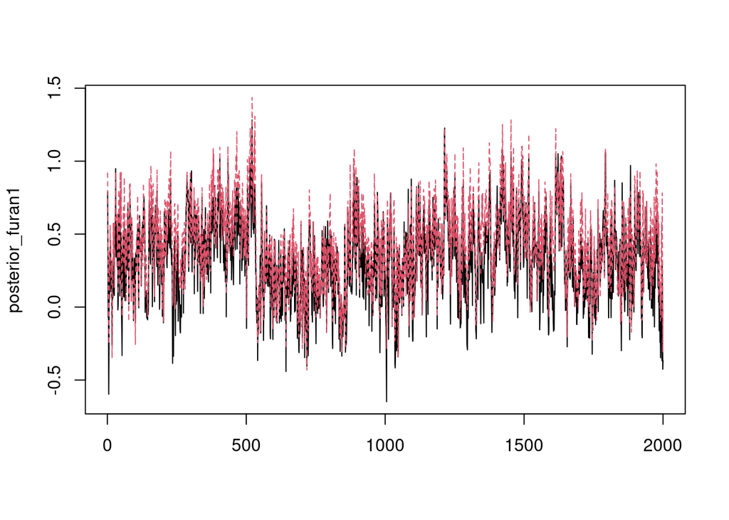

```r
matplot(posterior_furan1, type="l")
```

```r
posterior_furan1_difference <- posterior_furan1[,"q75"] - posterior_furan1[,"q25"]
length(posterior_furan1_difference)
```

```
## [1] 2000
```

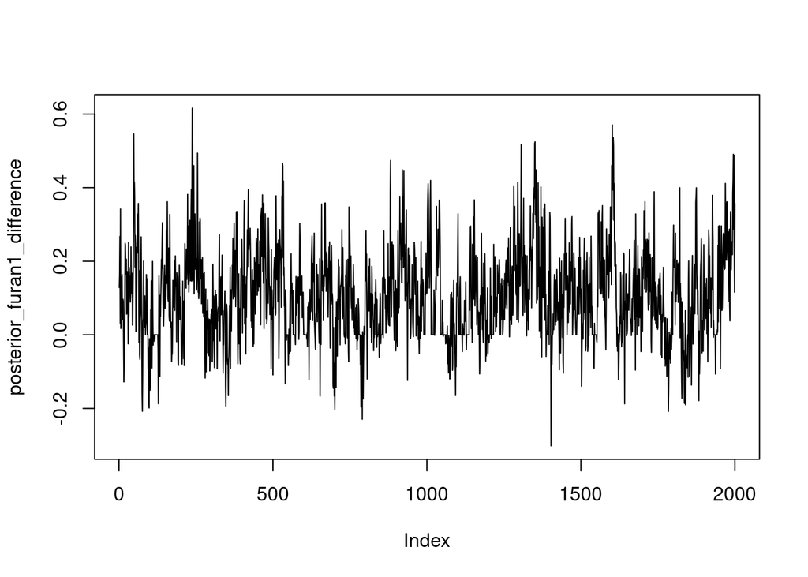

```r
plot(posterior_furan1_difference, type="l")
```

Last, we summarize the posterior distribution of the difference. We can summarize this in any way we want.

```r
# posterior mean difference is the point estimate or expected difference in response between these two exposure scenarios.
mean(posterior_furan1_difference)
```

```
## [1] 0.1076893
```

```r
# The 0.025 and 0.975 quantiles are the bounds of the 0.95 credible interval. This is similar to a confidence interval, but has slightly different interpretation.
quantile(posterior_furan1_difference, c(0.025,0.975))
```

```
##       2.5%      97.5%
## -0.1078312  0.3774525
```

```r
# the proportion of samples greater than 0 is interpreted as the probability that the mean response at the 0.75 quantile is greater than at the 0.25 quantile. It is somewhat like a p-value for a one-sided test.
mean(posterior_furan1_difference>0)
```

```
## [1] 0.774
```

## Estimation a contrast in one exposure averaged over all other predictors

We can estimate an IQR change in furan 1 averaged over all other covaraites. This is similar to the last example, but has a few extra steps.

Like before, we start by setting up the data. This time we do it separately for each level of furan 1. We also use the full dataset for prediction not just the means. The first step is to create two copies of the dataset, one for each quantile. For each dataset we will set furan 1 to either the 25th or 75th percentiles. All other variables remain the same as in the exposure dataset.

```r
# create two replicates of the data
data_q25 <- cbind(mixture,covariates)
data_q75 <- cbind(mixture,covariates)

# Find the 25th and 75th quantiles of furan 1
furan_qntls <- quantile(mixture[,"Furan1"], probs=c(0.25,0.75))

# for each dataset assign all individuals the specified level of furan 1
data_q25[,"Furan1"] <- furan_qntls[1]
data_q75[,"Furan1"] <- furan_qntls[2]

# check data
round(head(data_q25),2)
```

```
##      PCB74 PCB99 PCB118 PCB138 PCB153 PCB170 PCB180 PCB187 PCB194 PCB169 PCB126
## [1,]  3.17  3.70   3.69   3.04   3.04   3.15   3.01   3.41   4.09   2.29   1.77
## [2,]  2.23  2.83   2.33   2.17   2.16   2.26   2.01   2.76   2.40   1.14   0.77
## [3,]  3.32  2.15   2.15   2.23   2.00   2.16   1.88   2.41   1.68   1.94   1.73
## [4,]  2.43  2.80   2.40   2.16   2.17   2.02   1.84   2.11   2.00   1.83   0.89
## [5,]  2.22  2.31   1.48   2.26   2.07   2.25   1.93   2.40   2.08   1.58   0.48
## [6,]  2.35  2.90   2.44   2.21   2.00   1.78   1.81   2.50   1.92   1.45   1.29
##      Dioxin1 Dioxin2 Dioxin3 Furan1 Furan2 Furan3 Furan4 age_cent male bmi_cat3
## [1,]    0.19   -1.62   -0.31  -0.85  -0.94  -0.49  -2.10       42    1        1
## [2,]    1.69    2.06    2.83  -0.85   2.21   2.37   1.57       42    0        3
## [3,]    1.46    0.99    1.33  -0.85   1.62   1.51   0.71       30    0        3
## [4,]    1.30    0.68    0.75  -0.85   1.38   1.81   1.59       38    0        1
## [5,]    1.84    0.43    2.02  -0.85   2.34   2.07   1.84        5    0        1
## [6,]    1.30    0.49    1.51  -0.85   1.69   1.88   1.11       27    1        2
##      edu_cat race_cat LBXWBCSI LBXLYPCT LBXMOPCT LBXNEPCT LBXEOPCT LBXBAPCT
## [1,]       1        4      4.4     25.7     11.4     59.5      2.7      0.6
## [2,]       1        3      5.9     32.6      5.5     60.2      1.5      0.2
## [3,]       1        3      7.8     14.8      8.0     73.1      3.6      0.6
## [4,]       3        4      6.2     18.9     10.4     68.5      1.7      0.4
## [5,]       1        3      5.7     62.2     11.5     21.2      4.7      0.4
## [6,]       3        4     13.2     43.7      6.9     41.4      7.3      0.6
##      ln_lbxcot
## [1,]     -4.51
## [2,]     -2.23
## [3,]     -0.42
## [4,]     -3.61
## [5,]      5.87
## [6,]     -3.08
```

```r
round(head(data_q75),2)
```

```
##      PCB74 PCB99 PCB118 PCB138 PCB153 PCB170 PCB180 PCB187 PCB194 PCB169 PCB126
## [1,]  3.17  3.70   3.69   3.04   3.04   3.15   3.01   3.41   4.09   2.29   1.77
## [2,]  2.23  2.83   2.33   2.17   2.16   2.26   2.01   2.76   2.40   1.14   0.77
## [3,]  3.32  2.15   2.15   2.23   2.00   2.16   1.88   2.41   1.68   1.94   1.73
## [4,]  2.43  2.80   2.40   2.16   2.17   2.02   1.84   2.11   2.00   1.83   0.89
## [5,]  2.22  2.31   1.48   2.26   2.07   2.25   1.93   2.40   2.08   1.58   0.48
## [6,]  2.35  2.90   2.44   2.21   2.00   1.78   1.81   2.50   1.92   1.45   1.29
##      Dioxin1 Dioxin2 Dioxin3 Furan1 Furan2 Furan3 Furan4 age_cent male bmi_cat3
## [1,]    0.19   -1.62   -0.31   0.79  -0.94  -0.49  -2.10       42    1        1
## [2,]    1.69    2.06    2.83   0.79   2.21   2.37   1.57       42    0        3
## [3,]    1.46    0.99    1.33   0.79   1.62   1.51   0.71       30    0        3
## [4,]    1.30    0.68    0.75   0.79   1.38   1.81   1.59       38    0        1
## [5,]    1.84    0.43    2.02   0.79   2.34   2.07   1.84        5    0        1
## [6,]    1.30    0.49    1.51   0.79   1.69   1.88   1.11       27    1        2
##      edu_cat race_cat LBXWBCSI LBXLYPCT LBXMOPCT LBXNEPCT LBXEOPCT LBXBAPCT
## [1,]       1        4      4.4     25.7     11.4     59.5      2.7      0.6
## [2,]       1        3      5.9     32.6      5.5     60.2      1.5      0.2
## [3,]       1        3      7.8     14.8      8.0     73.1      3.6      0.6
## [4,]       3        4      6.2     18.9     10.4     68.5      1.7      0.4
## [5,]       1        3      5.7     62.2     11.5     21.2      4.7      0.4
## [6,]       3        4     13.2     43.7      6.9     41.4      7.3      0.6
##      ln_lbxcot
## [1,]     -4.51
## [2,]     -2.23
## [3,]     -0.42
## [4,]     -3.61
## [5,]      5.87
## [6,]     -3.08
```

Second, we predict with each new dataset.

```r
posterior_furan1_q25 <- predict(fit_bart, newdata = data_q25)
```

```
## *****In main of C++ for bart prediction
## tc (threadcount): 1
## number of bart draws: 2000
## number of trees in bart sum: 200
## number of x columns: 30
## from x,np,p: 30, 1003
## ***using serial code
```

```r
posterior_furan1_q75 <- predict(fit_bart, newdata = data_q75)
```

```
## *****In main of C++ for bart prediction
## tc (threadcount): 1
## number of bart draws: 2000
## number of trees in bart sum: 200
## number of x columns: 30
## from x,np,p: 30, 1003
## ***using serial code
```

```r
dim(posterior_furan1_q25)
```

```
## [1] 2000 1003
```

Third, we take the average of all 1003 observations for all datasets at each iteration. Each row in the posterior is one iteration and we want to keep these iterations linked throughout. This is done separately for each of our replicate datasets. The result is a vector with one observation for each MCMC iteration. We can interpret this as the posterior sample (MCMC sample) of the mean response in our sample if everyone had furan 1 fixed at the specified quantile and their other variables were as observed in the data. This naturally accounts for effect heterogeneity.

```r
# row mean for each quantile
posterior_furan1_q25 <- rowMeans(posterior_furan1_q25)
posterior_furan1_q75 <- rowMeans(posterior_furan1_q75)

# combine those results into a data frame with two columns
posterior_furan1_means <- cbind(posterior_furan1_q25,posterior_furan1_q75)
dim(posterior_furan1_means)
```

```
## [1] 2000    2
```

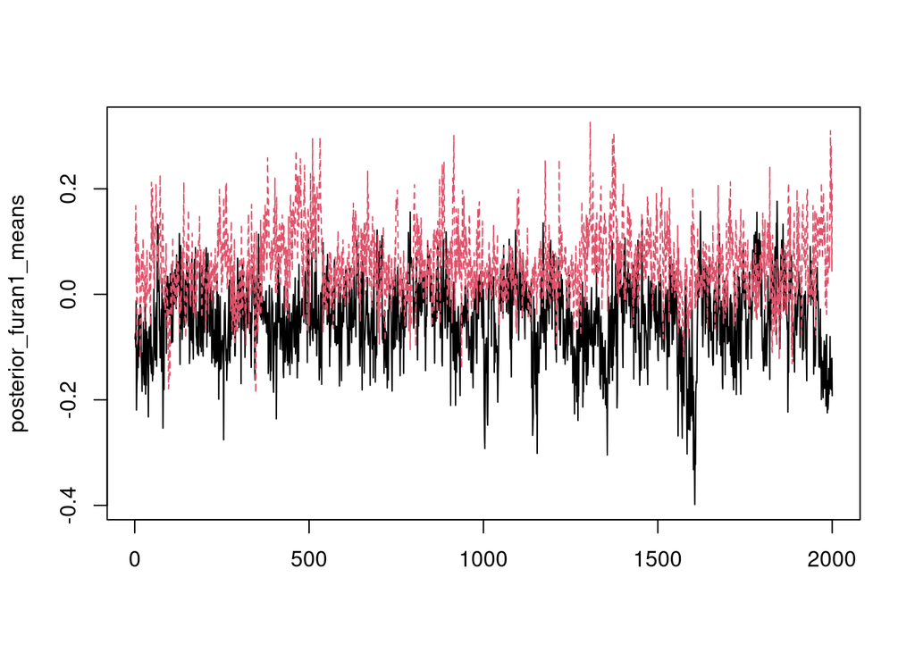

```r
colnames(posterior_furan1_means) <- c("q25","q75")

# visualize with a trace plot
matplot(posterior_furan1_means, type="l")
```

Then we take the difference at each iteration, just like before. Each row in the posterior is one iteration.

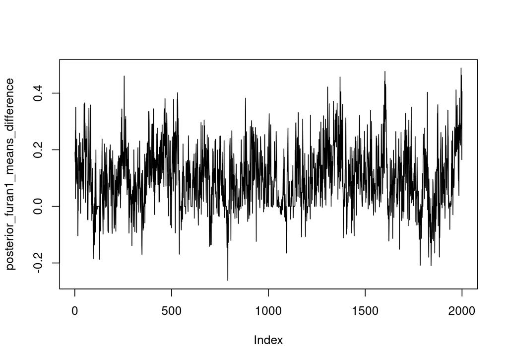

```r
posterior_furan1_means_difference <- posterior_furan1_means[,"q75"] - posterior_furan1_means[,"q25"]
plot(posterior_furan1_means_difference, type="l")
```

Last, we summarize the posterior distribution of the difference, just like before.

```r
mean(posterior_furan1_means_difference)
```

```
## [1] 0.1010294
```

```r
quantile(posterior_furan1_means_difference, c(0.025,0.975))
```

```
##        2.5%       97.5%
## -0.09356924  0.33022079
```

```r
mean(posterior_furan1_means_difference>0)
```

```
## [1] 0.8
```

## Partial dependence functions

To get partial dependence functions we can replicate the above procedure for estimates averaged over the other variables. This is done several times, For example, we may do this at every 5th quantile of a variable and then plot the results. The code below does this over a grid of L values, which can be specified. The partial dependence functions with BART include uncertainty.

```r
# partial dependence of BART
funan1_pd <- partialdependence1(fit_bart,
                                data=cbind(mixture,covariates),
                                exposures = "Furan1",
                                L=50)
```

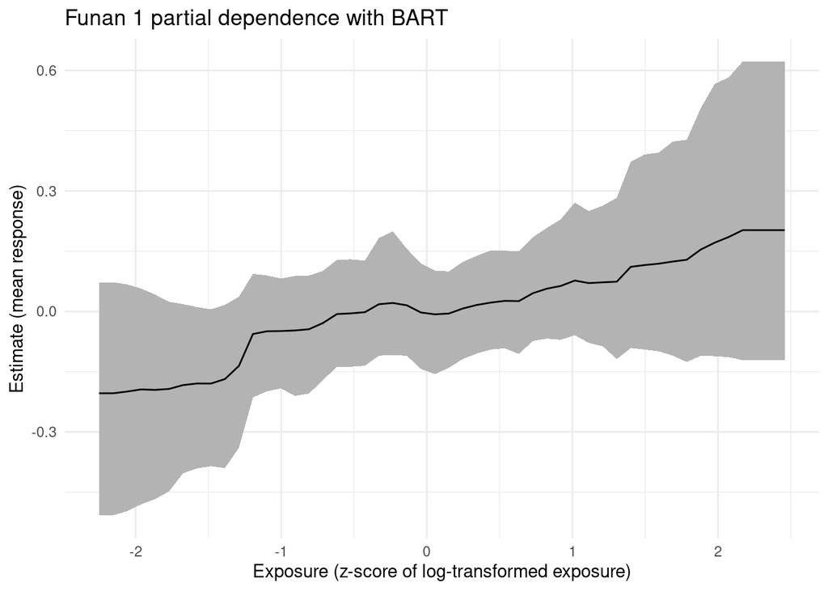

```r
ggplot(funan1_pd, aes(x=x, y=mean, ymin=lower, ymax=upper)) +
  geom_ribbon(fill="grey70") +
  geom_line() +
  theme_minimal() +
  ggtitle("Funan 1 partial dependence with BART") +
  xlab("Exposure (z-score of log-transformed exposure)") +
  ylab("Estimate (mean response)")
```

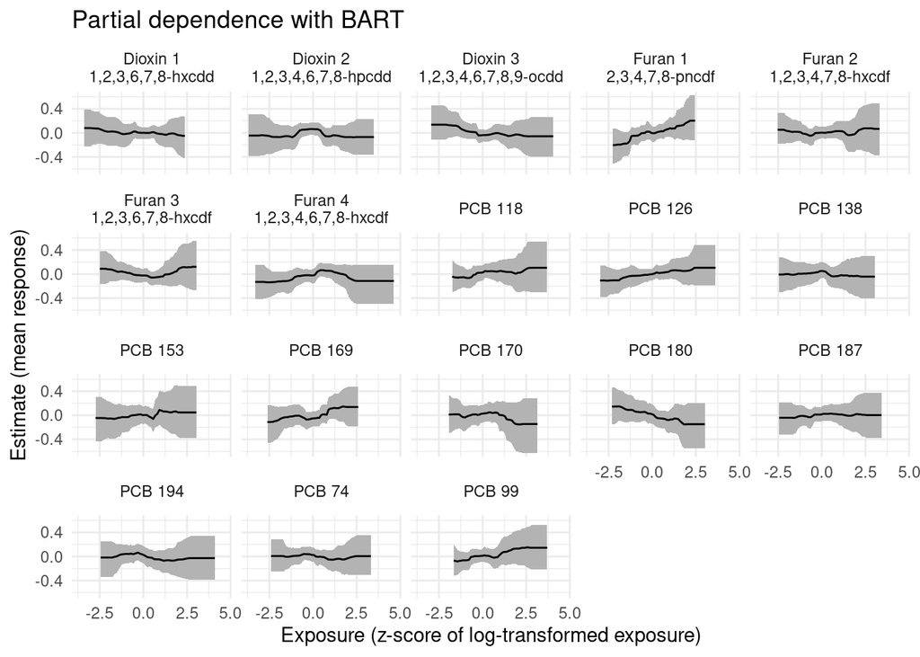

```r
plt <- all_pd %>%
mutate(exposure = fct_recode(exposure, "PCB 74" = "PCB74",
                                "PCB 99" = "PCB99",
                                "PCB 118" = "PCB118",
                                "PCB 138" = "PCB138",
                                "PCB 153" = "PCB153",
                                "PCB 170" = "PCB170",
                                "PCB 180" = "PCB180",
                                "PCB 187" = "PCB187",
                                "PCB 194" = "PCB194",
                                "Dioxin 1\n1,2,3,6,7,8-hxcdd" = "Dioxin1",
                                "Dioxin 2\n1,2,3,4,6,7,8-hpcdd" = "Dioxin2",
                               "Dioxin 3\n1,2,3,4,6,7,8,9-ocdd" =  "Dioxin3",
                               "Furan 1\n2,3,4,7,8-pncdf" =  "Furan1",
                               "Furan 2\n1,2,3,4,7,8-hxcdf" =  "Furan2",
                               "Furan 3\n1,2,3,6,7,8-hxcdf" =  "Furan3",
                               "Furan 4\n1,2,3,4,6,7,8-hxcdf" =  "Furan4",
                               "PCB 169" =  "PCB169",
                                "PCB 126" = "PCB126")) %>%
  ggplot(aes(x=x, y=mean, ymin=lower, ymax=upper)) +
  facet_wrap(~exposure) +
  geom_ribbon(fill="grey70") +
  geom_line() +
  theme_minimal() +
  ggtitle("Partial dependence with BART") +
  xlab("Exposure (z-score of log-transformed exposure)") +
  ylab("Estimate (mean response)")
plt
```

## 2-way partial dependence functions

```r
pd_2way <- partialdependence2(fit_bart,
                                data=cbind(mixture,covariates),
                                var = "PCB169",
                              var2 = "Furan1",
                              qtls = c(0.1,0.25,0.5,0.75,0.9),
                                L=20)
```

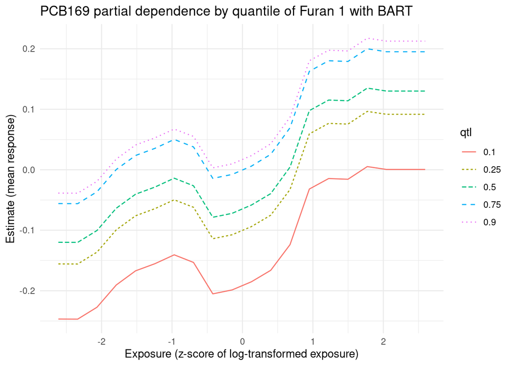

```r
pd_2way$qtl <- as.factor(pd_2way$qtl)
ggplot(pd_2way, aes(x=x, y=mean,
                    color=qtl,
                    linetype=qtl)) +
  geom_line() +
  theme_minimal() +
  ggtitle("PCB169 partial dependence by quantile of Furan 1 with BART") +
  xlab("Exposure (z-score of log-transformed exposure)") +
  ylab("Estimate (mean response)")
```

## Total mixture effect

```r
totalmix <- totalmixtureeffect(fit_bart,
                               data=cbind(mixture,covariates),
                               exposures = exposure_names,
                               qtls = seq(0.2,0.8,0.05))
```

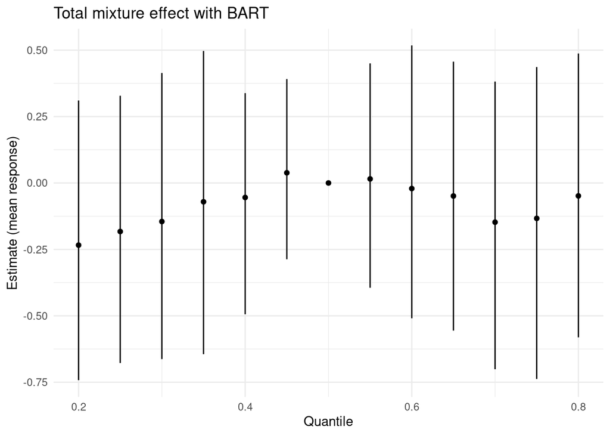

```r
ggplot(totalmix, aes(x=quantile, y=mean, ymin=lower, ymax=upper)) +
  geom_errorbar(width=0) + geom_point() + theme_minimal() +
  ggtitle("Total mixture effect with BART") +
  xlab("Quantile") +
  ylab("Estimate (mean response)")
```

## Subgroup specific effects

BART naturally accounts for heterogeneity. Because we included all exposures and covariates into the model there can be interactions both among exposures and among exposures and covariates. There are two approaches to estimate subgroup specific effects 1. Estimate the exposure effects with each subgroup. Using this approach, the effect in each group is conditional of the distribution of covariates and co-exposures observed in each group, which may be different among groups. 2. Use a g-computation-type approach to balance covariates and co-exposures across the groups.

First, we can estimate the exposure-response relationship in different subgroups (approach 1 above). Below we estimate the partial dependence function for Furan 1 among males and females. This is from the same model fit as before. We are simply using the posterior sample to estimate a different estimand.

The first step is to subset the data based on the subgroups of interest.

```r
combind_data <- cbind(mixture,covariates)
male_data_subset <- combind_data[which(combind_data[,"male"]==1),]
female_data_subset <- combind_data[which(combind_data[,"male"]==0),]

# dimension and distribution of male in combined data
dim(combind_data)
```

```
## [1] 1003   30
```

```r
table(combind_data[,"male"])
```

```
##
##   0   1
## 559 444
```

```r
# dimension and distribution of male in male only data
dim(male_data_subset)
```

```
## [1] 444  30
```

```r
table(male_data_subset[,"male"])
```

```
##
##   1
## 444
```

```r
# dimension and distribution of male in female only data
dim(female_data_subset)
```

```
## [1] 559  30
```

```r
table(female_data_subset[,"male"])
```

```
##
##   0
## 559
```

Next, estimate the partial dependence function for each subgroup. Alternatively, estimate the total mixture effect or interactions.

```r
# estimate among males with male subset of data
funan1_pd_male_subset <- partialdependence1(fit_bart,
                                 data=male_data_subset,  # subset of data provided
                                 exposures = "Furan1",
                                 L=50)

# estimate among females with female subset of data
funan1_pd_female_subset <- partialdependence1(fit_bart,
                                     data=female_data_subset,   # subset of data provided
                                     exposures = "Furan1",
                                     L=50)
```

Finally, we can visualize the difference.

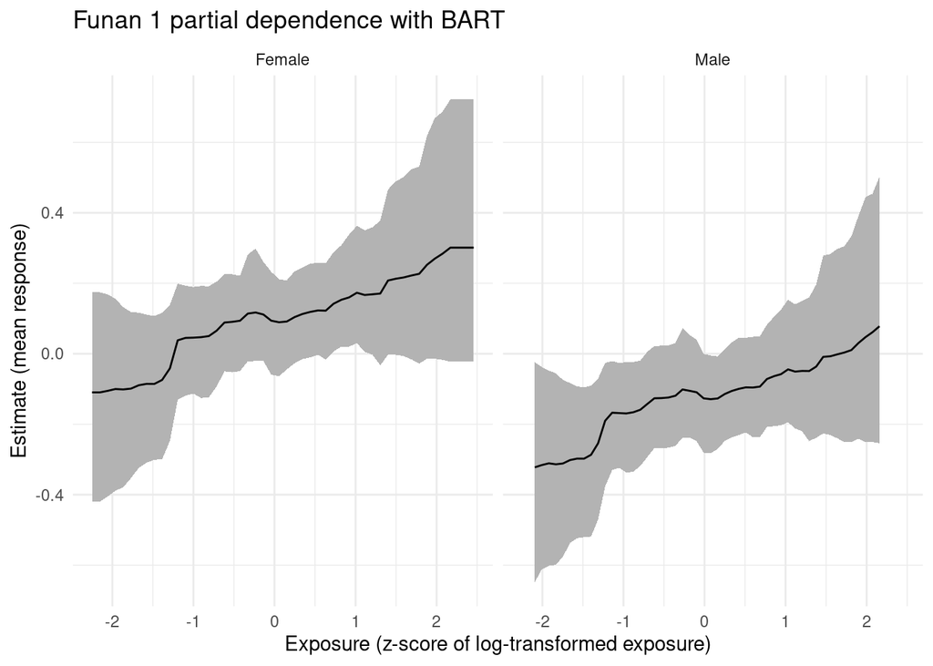

```r
funan1_pd_male_subset$subgroup <- "Male"
funan1_pd_female_subset$subgroup <- "Female"
funan1_pd_mf_subset <- rbind(funan1_pd_male_subset,funan1_pd_female_subset)
ggplot(funan1_pd_mf_subset, aes(x=x, y=mean, ymin=lower, ymax=upper)) +
  geom_ribbon(fill="grey70") +
  geom_line() +
  theme_minimal() +
  ggtitle("Funan 1 partial dependence with BART") +
  xlab("Exposure (z-score of log-transformed exposure)") +
  ylab("Estimate (mean response)")  +
  facet_grid(.~subgroup)
```

An alternative approach is to use the full dataset but set all individuals to male or female. This eliminates differences in the distribution of covariates between the two groups (e.g. differences in age, BMI, exposures, etc.). This is very similar to the approach used above to average over levels of co-exposures and covariates.

First, create the combined datasets.

```r
combind_data_allmale <- combind_data
combind_data_allmale[,"male"] <- 1

combind_data_allfemale <- combind_data
combind_data_allfemale[,"male"] <- 0



# dimension and distribution of male in combined data
dim(combind_data)
```

```
## [1] 1003   30
```

```r
table(combind_data[,"male"])
```

```
##
##   0   1
## 559 444
```

```r
# dimension and distribution of male in male only data
dim(combind_data_allmale)
```

```
## [1] 1003   30
```

```r
table(combind_data_allmale[,"male"])
```

```
##
##    1
## 1003
```

```r
# dimension and distribution of male in female only data
dim(combind_data_allfemale)
```

```
## [1] 1003   30
```

```r
table(combind_data_allfemale[,"male"])
```

```
##
##    0
## 1003
```

Next, estimate the partial dependence using each dataset.

```r
funan1_pd_male_all <- partialdependence1(fit_bart,
                                     data=combind_data_allmale,
                                     exposures = "Furan1",
                                     L=50)

funan1_pd_female_all <- partialdependence1(fit_bart,
                                       data=combind_data_allfemale,
                                       exposures = "Furan1",
                                       L=50)
```

Finally, graph the results.

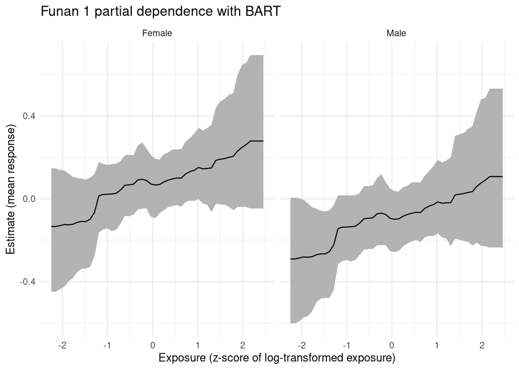

```r
funan1_pd_male_all$subgroup <- "Male"
funan1_pd_female_all$subgroup <- "Female"
funan1_pd_mf_all <- rbind(funan1_pd_male_all,funan1_pd_female_all)
ggplot(funan1_pd_mf_all, aes(x=x, y=mean, ymin=lower, ymax=upper)) +
  geom_ribbon(fill="grey70") +
  geom_line() +
  theme_minimal() +
  ggtitle("Funan 1 partial dependence with BART") +
  xlab("Exposure (z-score of log-transformed exposure)") +
  ylab("Estimate (mean response)")  +
  facet_grid(.~subgroup)
```